# Nutrient dynamics at the interface between surface water and groundwater with aquatic vegetation in Cikapundung river

Dasapta Erwin Irawan

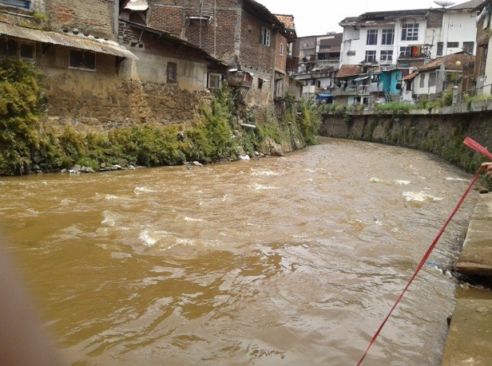

Cikapundung river (`@dasaptaerwin` via [Rockheadsciences website](http://rockheadsciences.com/irawan-riverbank-hydrochemistry/))

# 1 general

This repository hosts files related to the following project **Nutrient dynamics at the interface between surface water and groundwater with aquatic vegetation in Cikapundung river**. This project is funded by Kemenristekdikti 2018. The posts in this document were upload as log notebook to the Simlitabmas Server.

# 2 how to use this repository

Go to: - `notebook.md` to read the progress of this project. - `license.md` to read the MIT license agreement (equivalent to CC-BY license)

# 3 who’s behind the scene

Principal team:

- [Dasapta Erwin Irawan (PI, ITB)](https://scholar.google.co.id/citations?user=Myvc78MAAAAJ&hl=en) and
- [Deny Juanda Puradimaja (Co-PI, ITB)](https://scholar.google.co.id/citations?user=-Z9rgsQAAAAJ&hl=en)
- [Achmad Darul](https://scholar.google.co.id/citations?user=pssCw68AAAAJ&hl=en)
- and honouring [Dr. Budi Brahmantyo](https://scholar.google.com/citations?hl=en&user=t7CtT5MAAAAJ&view_op=list_works&sortby=pubdate) who passed away along the way earlier this year

Collaborators:

This project serves as field lab for Groundwater Engineering Master Program and Geology Undergraduate Program of Institut Teknologi Bandung. Hence, massive participation from students are the main collaborator.

- A group of undergrad students led by [Ahmad Jawwad Furqon](https://twitter.com/ahmadjfurqon)
- A group of graduate students led by [Dimas Maulana Wibowo](https://scholar.google.co.id/citations?user=M22VJuEAAAAJ&hl=en&oi=ao)
- Rendi Armansyah, graduate student, Groundwater Engineering Program.